# Analyzing Swecris, Case, Cordis, and OpenAire Datasets

Author

Affiliation

Mohamad Bazzi

KTH Royal Institute of Technology

## Text blurb

Rationale — To enhance existing information in CASE by supplementing missing or incomplete data.

```r
R.packages <- c("devtools","dplyr","swecris","kthapi","grid",
                "gridExtra","stringdist","knitr","quarto","ggfittext","xml2",
                "ReDaMoR","gt","janitor","ggplot2","ggpubr","purrr","XML",
                "RecordLinkage","flextable","colorspace","fastLink",
                "magrittr","kableExtra","VennDiagram","cld2","PGRdup",
                "fuzzyjoin","naniar","furrr","stringr","qpcR","dlookr",
                "cordis","bibliotools","OpenAIRE","duckdb","ggalluvial","gapminder",
                "circlize","networkD3","wordcloud","ggwordcloud","RColorBrewer")

invisible(lapply(R.packages, library, character.only = TRUE))
```

```r
source(file = "C:/Repos/swecris/data-raw/customFunction.R")
```

## Data sources

```r
# Download all sweCris funding data.
swe.Total <- swecris_fundings() # 223 737 rows.

# sweCris data (KTH only: 3137 observations as of 2023-02-16)
sw.Df <- swecris_kth

# CASE data (2593 observations)
ca.Df <- bibliotools::case()

# Adjust column names.
colnames(ca.Df)[16] <- "ProjectNumber"
colnames(ca.Df)[14] <- "PrimaryResearcher"
colnames(ca.Df)[6] <- "FundingOrganisation"
```

[figure not shown]

Data-driven flowchart (keys).

```r
include_graphics("C:/Repos/swecris/analytic-img/DataDriven-Flowchart.png")
```

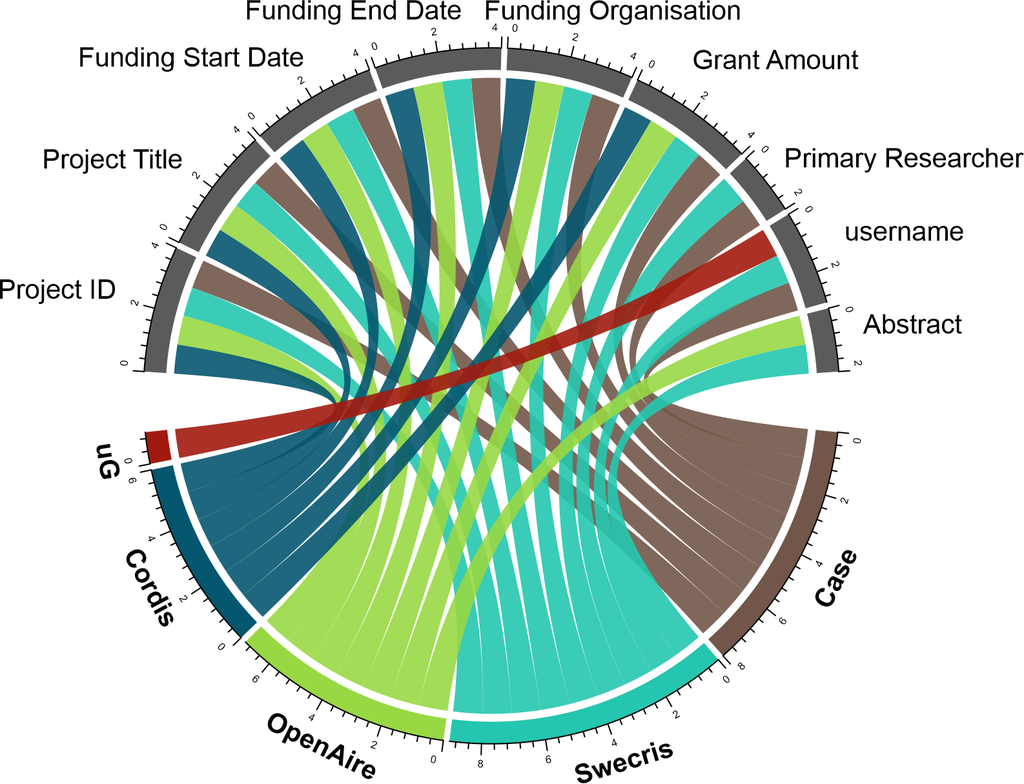

Entity/Relationship (ER) diagram.

```r
include_graphics("C:/Repos/swecris/analytic-img/entityGraph.png")
```

```r
db_connections <- read.csv2(file = "C:/Repos/swecris/data-raw/alluvial-graph-data.csv",header = T)
# Plot.
# chordDiagram(db_connections,
#              col = cols,
#             transparency = 0.1,
#             link.lwd = 2,
#             link.lty = 2)

# circos.clear()
```

## CASE data-quality

```r
ca_figure_a <- bazzi.na.Total(x = ca.Df, col = "black",typographic = T) +
  theme(axis.text.x = element_text(size = 9,angle = 45),
        axis.title.x = element_text(size = 9),
        axis.title.y = element_text(size = 9),
        axis.title.y.right = element_text(size = 9),
        panel.grid.major = element_blank(),
        panel.grid.minor = element_blank())
```

### CASE data-quality by school

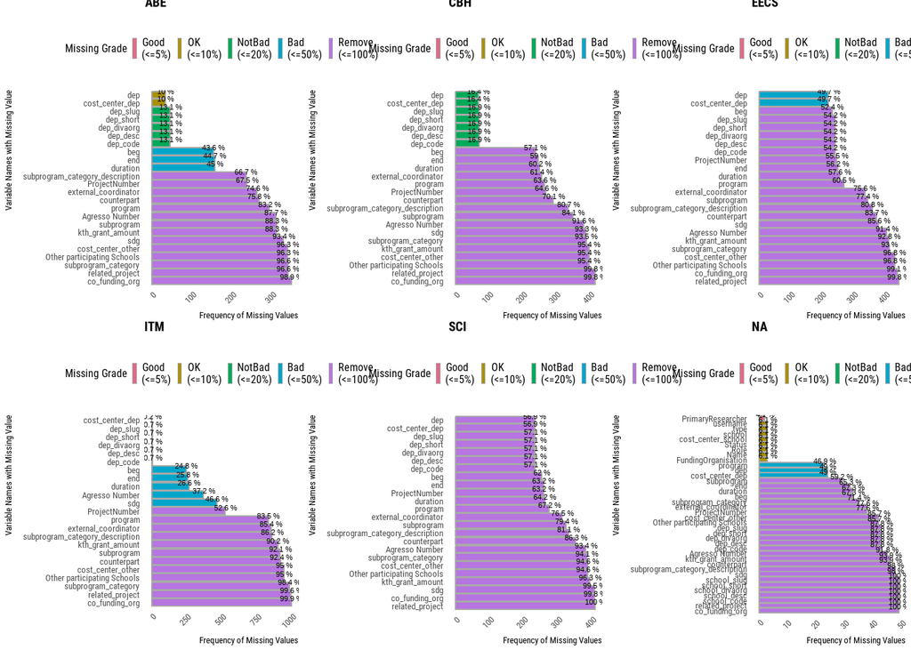

Pareto chart for missing values by school in CASE. Only variables with missing values are included.

```r
# School data-frame.
ca.school <- ca.Df
ca.school$school_short <- as.factor(ca.school$school_short)
# Split data-frame by factor.
school <- ca.school %>%
  group_by(school_short)
# Droplevels, set names, and plot.
split.school <- group_split(school)

for(i in seq_along(split.school)) {
  split.school[[i]]$school_short <- droplevels(split.school[[i]]$school_short)
}

schoolName <- c("ABE","CBH","EECS","ITM","SCI")

ls.plot <- list()

for(i in seq_along(split.school)) {
  out <- split.school[[i]] %>%
    bazzi.na.Partial(only_na = TRUE,col = "blue",typographic = T,
                   main = schoolName[i]) +
    theme(axis.text.x = element_text(size = 5),
          axis.text.y = element_text(size = 5),
          axis.title.x = element_text(size = 5),
          axis.title.y = element_text(size = 5),
          axis.title.y.right = element_text(size = NULL),
          plot.title = element_text(size=7),
          legend.title = element_text(size = 6),
          legend.text = element_text(size = 6),
          legend.key.size = unit(1,"mm"),
          legend.key.height= unit(1, 'mm'),
          legend.key.width= unit(1, 'mm'),
          plot.margin=unit(c(-0.5,1,1,1), "mm"),
          panel.grid.major = element_blank(),
          panel.grid.minor = element_blank()) +
    coord_flip()
  ls.plot[[i]] <- out
}

do.call("grid.arrange", c(ls.plot, ncol=3))
```

## Swecris data-quality

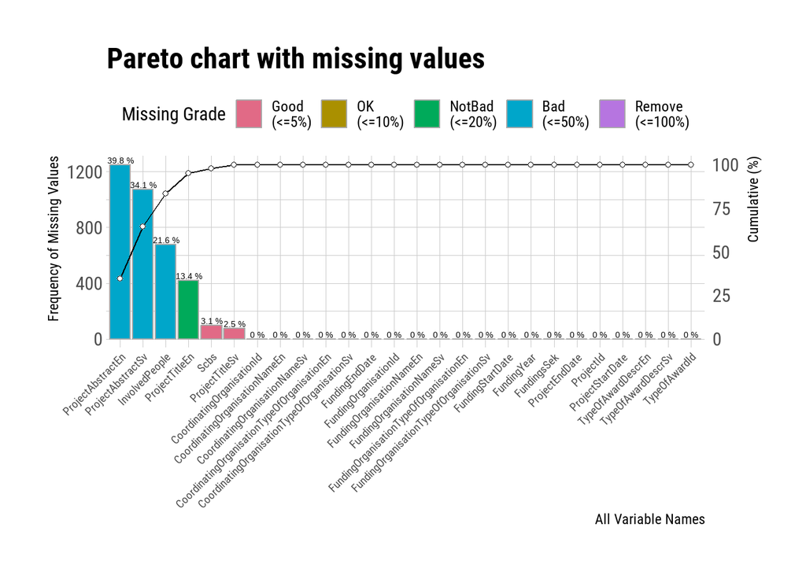

Pareto chart for missing values (counts and proportions) in Swecris

```r
# Convert all Unknown to NA.
sw.Df[,] <- apply(sw.Df, 2, function(x) ifelse(x == "Unknown", NA, x))
# Plot.
bazzi.na.Total(x = sw.Df, col = "black",typographic = T) +
  theme(axis.text.x = element_text(size = 7),
        axis.title.x = element_text(size = 9),
        axis.title.y = element_text(size = 9),
        axis.title.y.right = element_text(size = 9))
```

In the sweCris dataset, the column-wise completeness is generally satisfactory. The only notable exceptions are the abstract fields in both Swedish and English, which tend to have a high prevalence of missing data. Additionally, the project title in English is not consistently recorded with a high degree of accuracy. The involved people field is also not 100% complete.

#### What does Swecris contain not present in Case?

#### Range

```r
range(ca.Df$beg,na.rm = T) # Case - 2009
```

```
[1] "2009-03-01" "2024-03-20"
```

```r
range(sw.Df$FundingStartDate) # sweCris - 2008
```

```
[1] "2008-01-01" "2023-01-01"
```

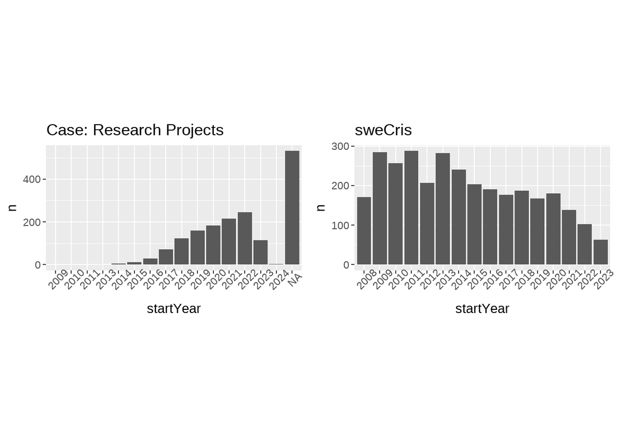

```r
# Number of Research Projects by Funding Start Year?
ca.Df["startYear"] <- format(ca.Df$beg,"%Y")
sw.Df["startYear"] <- format(as.Date(sw.Df$FundingStartDate),"%Y")
# Check Case.
k_1 <- ca.Df %>% group_by(type,startYear) %>%
  filter(type == "Research project") %>%
  count(sort = F) %>%
  ggplot2::ggplot(mapping = aes(x = startYear,y = n)) +
  labs(title = "Case: Research Projects") +
  geom_col() +
  scale_fill_manual(values = c("NA" = "red")) +
  theme(axis.text.x = element_text(angle = 45))
# Check sweCris
k_2 <- sw.Df %>% group_by(startYear) %>%
  count(sort = F) %>%
  ggplot2::ggplot(mapping = aes(x = startYear,y = n)) +
  labs(title = "sweCris") +
  geom_col() + theme(axis.text.x = element_text(angle = 45))

ggpubr::ggarrange(k_1,k_2) + theme(aspect.ratio = 1/3)
```

```r
## More sweCris graphics.
# Size of funding in sweCris along with the average.
sw_fund <- sw.Df %>% mutate(FundingsSek = as.numeric(FundingsSek)) %>%
  group_by(FundingsSek,startYear) %>%
  ggplot(mapping = aes(x = startYear, y = FundingsSek)) +
  scale_y_continuous(labels = scales::comma) +
  geom_hline(yintercept=mean(as.numeric(sw.Df$FundingsSek)), linetype="dashed",
                color = "red", size=1) +
  geom_point()

# Type of Award.
sw_award <- sw.Df %>% group_by(TypeOfAwardDescrEn) %>% count(sort = T) %>%
  ggplot(aes(x = reorder(TypeOfAwardDescrEn,-n), y = n)) +
  geom_col() + theme(axis.text.x = element_text(angle = 45, size = 6, vjust = .5)) +
  labs(x = "", title = "Type of Award", y = "") + coord_flip()
```

## 1A. Project number (Variable identifier)

- **Exact matches on ID**

The **Project number** variable in CASE correspond to the **Project ID** field in sweCris. However, to facilitate string intersection or matching, one is required to reformat the key in one of the datasets. A cursory view at the sweCris dataset reveal a predominantly consistent ID form/style. For that reason, I have chosen to use the sweCris ID format as a baseline for how to ‘clean’ CASE project numbers.

Exploratory data analysis reveal that the ID format in both datasets are organisation-specific (e.g. projects funded via the Swedish Energy Agency takes a unique form: see below). In the code that follows I have split the ‘cleaning’ procedure into first standardizing the Swedish Energy Agency funded project ID’s (including the removal of empty values , non-numeric characters, and the addition of letters at the beginning and end of each ID), and then applying a similar set of operations to the remaining project data. More specifically, I created a new field corresponding to a ‘clean ID’ with only numeric characters and hyphen symbols retained. This was then filtered to keep elements with 10 characters only. The chosen value is not arbitrary, but is a reflection of the number of elements found in the majority-class of ID’s in sweCris.

```r
# Subset CASE by Funding Organisation = Swedish Energy Agency.
sea.ca <- subset(ca.Df, FundingOrganisation == "Energimyndigheten")
# Remove NA and superfluous text.
sea.ca <- sea.ca[!is.na(sea.ca$ProjectNumber),]
sea.ca <- sea.ca[sea.ca$ProjectNumber %in% as.vector(na.omit(sea.ca$ProjectNumber[sapply(sea.ca$ProjectNumber, nchar) == 7])),]
# Add P to number strings.
sea.ca$ProjectNumber <- paste0("P", gsub("","",sea.ca$ProjectNumber))
# Add organisation name to string.
sea.ca$ProjectNumber <- paste(sea.ca$ProjectNumber,"_Energi")
sea.ca$ProjectNumber <- gsub("\\s","", sea.ca$ProjectNumber)
# Repeat: Keep numbers only.
ca.Df["clean.IDA"] <- gsub("[^0-9.-]","",ca.Df$ProjectNumber)
# Keep 10 character elements only.
ca.Df.sub <- ca.Df[ca.Df$clean.IDA %in% as.vector(na.omit(ca.Df$clean.IDA[sapply(ca.Df$clean.IDA, nchar) == 10])),] # 312 observations.
ca.Df.sub$clean.IDA <- gsub("^-","",ca.Df.sub$clean.IDA)
# Remove empty funding organisation.
ca.Df.sub$FundingOrganisation[ca.Df.sub$FundingOrganisation == "Not Applicable N/A"]  <- ""
# Standardize against sweCris names.
ca.Df.sub$FundingOrganisation <- recode(ca.Df.sub$FundingOrganisation,
                                        Energimyndigheten = "Energi",
                                        VINNOVA = "Vinnova",
                                        Vetenskapsrådet = "VR")

# Combine
ca.Df.sub["clean.IDA"] <- paste(ca.Df.sub$clean.IDA,
                                ca.Df.sub$FundingOrganisation,
                                sep = "_")

ca.Df.sub["clean.IDA"] <- gsub("^-","",ca.Df.sub$clean.IDA)

# Combine dataframes.
cleanID.CASE <- dplyr::bind_rows(sea.ca,ca.Df.sub) # 389 observations.
cleanID.CASE[1:77,"clean.IDA"] <- cleanID.CASE[1:77,"ProjectNumber"]
# Remove missing organisations.
cleanID.CASE <- cleanID.CASE[!cleanID.CASE$FundingOrganisation == "",] # 386 observations.
```

```r
# How many in 00000-0_ZZ shape in sweCris? They are all Energy funded
as.vector(na.omit(str_extract(sw.Df$ProjectId, "(\\d+)-(\\d{1})_[:alpha:]+"))) %>%
  length() # 369 (11.76%)
# How many in 0000-00000_ZZ format?
as.vector(na.omit(str_extract(sw.Df$ProjectId, "(\\d+)-(\\d{5})_[:alpha:]+"))) %>%
  length() # 2680 (85%). In total with the aforementioned = 97.19%
```

### Duplicates in CASE?

In total, there are 20 instances of duplicate project titles in CASE at the level research projects. These duplicate projects can be identified by their distinct project IDs and varying statuses, such as application, ongoing, or rejected.

```r
# Title duplicates in title name.
# ca.Df[duplicated(ca.Df["Name"], fromLast = T), ] %>% filter(!is.na(Name))

# Title duplicates in title names for research projects.
res_proj <- ca.Df[ca.Df$type == "Research project", ]
# na.omit(res_proj$Name[duplicated(res_proj$Name)]) %>% length
# Examine the projects with n > 1.
res_proj_dup <-
  ca.Df[ca.Df$Name %in% (res_proj$Name[duplicated(res_proj$Name)])[-c(1:2)],] %>%
  filter(type != "Research Infrastructure" & type != "Research Centra")
# Plot results.
ca_figure_b <- res_proj_dup %>%
  ggplot(mapping = aes(x = `Project ID`, fill = Status)) +
  geom_bar() + facet_wrap(.~Name+FundingOrganisation, scales = "free")
```

### Pattern expressions (Project Number)

```r
# How many different patterns are available in the Project Number field?
ids <- na.omit(ca.Df$ProjectNumber)
# Data frame.
ids.nchar <- data.frame(ids = ids,
                        char.num = nchar(ids),
                        name = ca.Df[ca.Df$ProjectNumber %in% ids,]$Name) # 1080 projects.

# At the character unit there are 37 levels.
# Each level (e.g., "10" may include several ID pattern expressions)
ids_expression <- ids.nchar %>%
  dplyr::group_by(char.num) %>% count(sort = T) %>% print(n = 37)
```

```
# A tibble: 38 × 2
# Groups:   char.num [38]
   char.num     n
      <int> <int>
 1       10   305
 2        6   231
 3        9   157
 4        7    88
 5       11    70
 6        5    49
 7        8    43
 8       12    17
 9       13    16
10       18    14
11       14    12
```

[output cut: 27 more lines]

```r
# Extract the values for a specific char.num
values_for_char_num <- ids.nchar %>%
  filter(char.num == 10) %>%
  pull(ids); attributes(values_for_char_num)$na.action <- NULL

# Plot.
ca_figure_c <- ids_expression %>%
  ggplot(mapping = aes(x = as.factor(char.num),y = n)) +
  geom_col() + theme(aspect.ratio = 1/2)

# Plot project types in Case.
ca_figure_d <- ca.Df %>% group_by(type) %>% count(sort = T) %>%
  ggplot(mapping = aes(x = reorder(type, -n),y = n)) +
  geom_col() + coord_flip() + theme(aspect.ratio = 1/2)
```

```r
# How many true project ID's are duplicated?
true_dup <- ids.nchar %>%
  dplyr::select(-starts_with("name")) %>%
  add_count(ids) %>%
  filter(n > 1) %>%
  distinct() # 8 in total.

# Are these the same projects or are they completely different?
ids.nchar %>%
  group_by(ids) %>%
  filter(n()>1) %>%
  ungroup() %>% arrange(desc(ids))
```

**NB:** This shows that the duplicated ID’s in Case correspond to different project titles at the level of research projects.